# NYPD Shooting

A Z Ullah

2022-06-18

### Reading in the data

Reading the data from the city of new york on [NYPD shooting incidents](https://data.cityofnewyork.us/Public-Safety/NYPD-Shooting-Incident-Data-Historic-/833y-fsy8) between 2006, january till 2021, december. [Link to video on vimeo](https://vimeo.com/721811311/c5a66f5068)

```r
data <- read_csv("https://data.cityofnewyork.us/api/views/833y-fsy8/rows.csv?accessType=DOWNLOAD")
```

### Summary of the data

Display a summary of the data imported:

```r
summary(data)
```

```
##   INCIDENT_KEY        OCCUR_DATE         OCCUR_TIME           BORO
##  Min.   :  9953245   Length:25596       Length:25596      Length:25596
##  1st Qu.: 61593633   Class :character   Class1:hms        Class :character
##  Median : 86437258   Mode  :character   Class2:difftime   Mode  :character
##  Mean   :112382648                      Mode  :numeric
##  3rd Qu.:166660833
##  Max.   :238490103
##
##     PRECINCT      JURISDICTION_CODE LOCATION_DESC      STATISTICAL_MURDER_FLAG
##  Min.   :  1.00   Min.   :0.0000    Length:25596       Mode :logical
##  1st Qu.: 44.00   1st Qu.:0.0000    Class :character   FALSE:20668
##  Median : 69.00   Median :0.0000    Mode  :character   TRUE :4928
##  Mean   : 65.87   Mean   :0.3316
##  3rd Qu.: 81.00   3rd Qu.:0.0000
##  Max.   :123.00   Max.   :2.0000
##                   NA's   :2
##  PERP_AGE_GROUP       PERP_SEX          PERP_RACE         VIC_AGE_GROUP
##  Length:25596       Length:25596       Length:25596       Length:25596
##  Class :character   Class :character   Class :character   Class :character
##  Mode  :character   Mode  :character   Mode  :character   Mode  :character
##
##
##
##
##    VIC_SEX            VIC_RACE           X_COORD_CD        Y_COORD_CD
##  Length:25596       Length:25596       Min.   : 914928   Min.   :125757
##  Class :character   Class :character   1st Qu.:1000011   1st Qu.:182782
##  Mode  :character   Mode  :character   Median :1007715   Median :194038
##                                        Mean   :1009455   Mean   :207894
##                                        3rd Qu.:1016838   3rd Qu.:239429
##                                        Max.   :1066815   Max.   :271128
##
##     Latitude       Longitude        Lon_Lat
##  Min.   :40.51   Min.   :-74.25   Length:25596
##  1st Qu.:40.67   1st Qu.:-73.94   Class :character
##  Median :40.70   Median :-73.92   Mode  :character
##  Mean   :40.74   Mean   :-73.91
##  3rd Qu.:40.82   3rd Qu.:-73.88
##  Max.   :40.91   Max.   :-73.70
##
```

### Wrangling the data

Perform the following data cleanup steps:

```r
data <- data %>% mutate(OCCUR_DATE = mdy(OCCUR_DATE)) %>%
                mutate(OCCUR_TIME = hms(OCCUR_TIME)) %>%
                mutate(JURISDICTION_CODE = factor(JURISDICTION_CODE)) %>%
###    select(-X_COORD_CD, -Y_COORD_CD, -Latitude, -Longitude , -Lon_Lat) %>% ###
              mutate(PERP_AGE_GROUP = factor(PERP_AGE_GROUP)) %>%                        mutate(VIC_AGE_GROUP = factor(VIC_AGE_GROUP)) %>%                          mutate(PERP_SEX = factor(PERP_SEX)) %>%
              mutate(PERP_RACE = factor(PERP_RACE)) %>%
              mutate(VIC_SEX = factor(VIC_SEX)) %>%
              mutate(VIC_RACE = factor(VIC_RACE))  %>%
              mutate(BORO = factor(BORO)) %>%
              filter(!is.na(JURISDICTION_CODE)) %>%                                      filter(!is.na(PERP_RACE)) %>%
              filter(!is.na(PERP_AGE_GROUP))  %>%
              filter(!is.na(PERP_SEX))
summary(data)
```

```
##   INCIDENT_KEY         OCCUR_DATE           OCCUR_TIME
##  Min.   :  9953245   Min.   :2006-01-01   Min.   :0S
##  1st Qu.: 46889811   1st Qu.:2008-06-01   1st Qu.:3H 46M 0S
##  Median : 76869678   Median :2011-01-16   Median :15H 22M 0S
##  Mean   : 98431415   Mean   :2012-05-25   Mean   :12H 55M 18.5686153846182S
##  3rd Qu.:150967597   3rd Qu.:2016-03-05   3rd Qu.:20H 38M 45S
##  Max.   :238490103   Max.   :2021-12-31   Max.   :23H 59M 0S
##
##             BORO         PRECINCT      JURISDICTION_CODE LOCATION_DESC
##  BRONX        :4890   Min.   :  1.00   0:13659           Length:16250
##  BROOKLYN     :6074   1st Qu.: 44.00   1:   46           Class :character
##  MANHATTAN    :2234   Median : 67.00   2: 2545           Mode  :character
##  QUEENS       :2461   Mean   : 65.49
##  STATEN ISLAND: 591   3rd Qu.: 81.00
##                       Max.   :123.00
##
##  STATISTICAL_MURDER_FLAG PERP_AGE_GROUP PERP_SEX
##  Mode :logical           18-24  :5844   F:  371
##  FALSE:13028             25-44  :5202   M:14414
##  TRUE :3222              UNKNOWN:3147   U: 1465
##                          <18    :1462
##                          45-64  : 535
##                          65+    :  57
##                          (Other):   3
##                           PERP_RACE     VIC_AGE_GROUP  VIC_SEX
##  AMERICAN INDIAN/ALASKAN NATIVE:    2   <18    :1869   F: 1710
##  ASIAN / PACIFIC ISLANDER      :  141   18-24  :6035   M:14532
##  BLACK                         :10667   25-44  :7043   U:    8
##  BLACK HISPANIC                : 1203   45-64  :1125
##  UNKNOWN                       : 1802   65+    : 123
##  WHITE                         :  272   UNKNOWN:  55
##  WHITE HISPANIC                : 2163
##                            VIC_RACE       X_COORD_CD        Y_COORD_CD
##  AMERICAN INDIAN/ALASKAN NATIVE:    7   Min.   : 920263   Min.   :128875
##  ASIAN / PACIFIC ISLANDER      :  257   1st Qu.: 999794   1st Qu.:183346
##  BLACK                         :11093   Median :1007915   Median :196451
##  BLACK HISPANIC                : 1639   Mean   :1009006   Mean   :209100
##  UNKNOWN                       :   47   3rd Qu.:1017119   3rd Qu.:240479
##  WHITE                         :  514   Max.   :1065474   Max.   :271128
##  WHITE HISPANIC                : 2693
##     Latitude       Longitude        Lon_Lat
##  Min.   :40.52   Min.   :-74.23   Length:16250
##  1st Qu.:40.67   1st Qu.:-73.94   Class :character
##  Median :40.71   Median :-73.91   Mode  :character
##  Mean   :40.74   Mean   :-73.91
##  3rd Qu.:40.83   3rd Qu.:-73.88
##  Max.   :40.91   Max.   :-73.71
##
```

```r
data
```

```
## # A tibble: 16,250 x 19
##    INCIDENT_KEY OCCUR_DATE OCCUR_TIME BORO      PRECINCT JURISDICTION_CODE
##           <dbl> <date>     <Period>   <fct>        <dbl> <fct>
##  1    225295736 2021-03-07 6H 15M 0S  BROOKLYN        75 0
##  2    231190175 2021-07-21 40M 0S     MANHATTAN       32 0
##  3    227950661 2021-05-09 2H 50M 0S  BRONX           41 2
##  4    229643172 2021-06-16 23H 22M 0S BRONX           52 0
##  5    222990833 2021-01-12 22H 12M 0S BROOKLYN        69 0
##  6    233149851 2021-09-04 20H 18M 0S MANHATTAN       32 0
##  7    229643172 2021-06-16 23H 22M 0S BRONX           52 0
##  8    234268729 2021-09-29 12H 50M 0S BRONX           48 0
##  9    225438895 2021-03-10 7H 30M 0S  MANHATTAN       28 0
## 10    232193235 2021-08-13 1H 0M 0S   QUEENS         109 0
## # ... with 16,240 more rows, and 13 more variables: LOCATION_DESC <chr>,
## #   STATISTICAL_MURDER_FLAG <lgl>, PERP_AGE_GROUP <fct>, PERP_SEX <fct>,
## #   PERP_RACE <fct>, VIC_AGE_GROUP <fct>, VIC_SEX <fct>, VIC_RACE <fct>,
## #   X_COORD_CD <dbl>, Y_COORD_CD <dbl>, Latitude <dbl>, Longitude <dbl>,
## #   Lon_Lat <chr>
```

### Visualizations

#### Visualization #1

Following is a bar chart of the number of incidents by BORO and colored by VIctim race

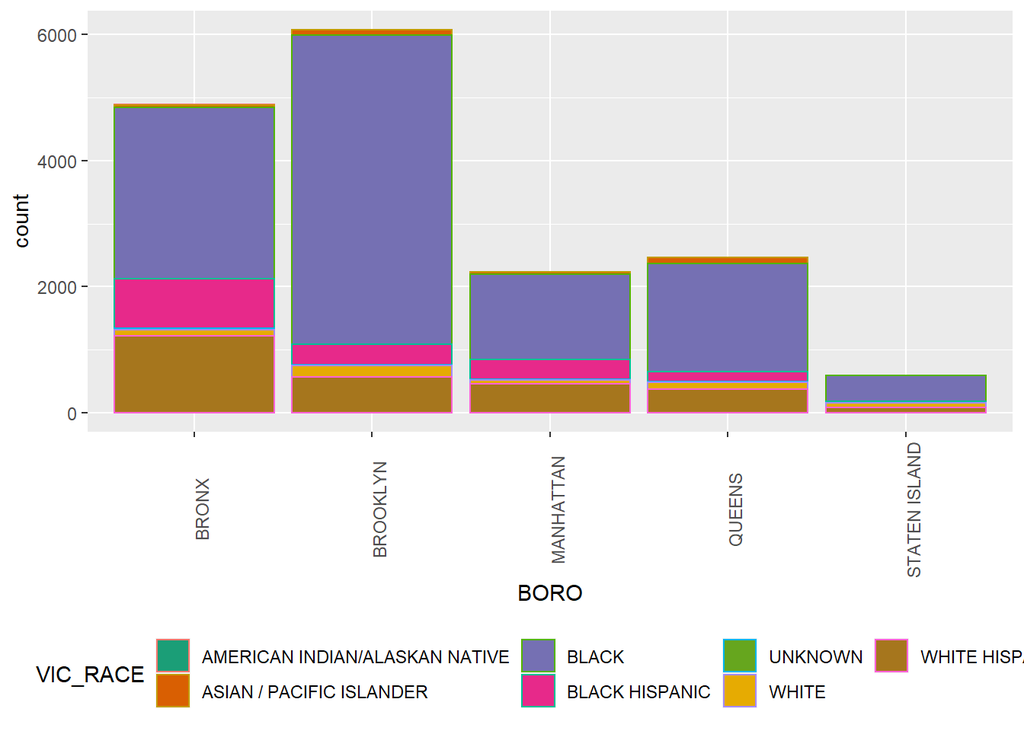

```r
ggplot(data = data) +
    geom_bar(mapping = aes(x = BORO, color = VIC_RACE, fill = VIC_RACE)) + theme(axis.text.x = element_text(angle = 90), legend.position="bottom") + scale_fill_brewer(palette="Dark2")
```

**The Brooklyn brorough has the higher number of incidents folllowed by the Bronx. Victim’s race of black seems to have the highest number of incidents across all boroughs.**

#### Visualization #2

**Following is a grid plot with rows being the victim’s race and columns being perpetrator’s race**

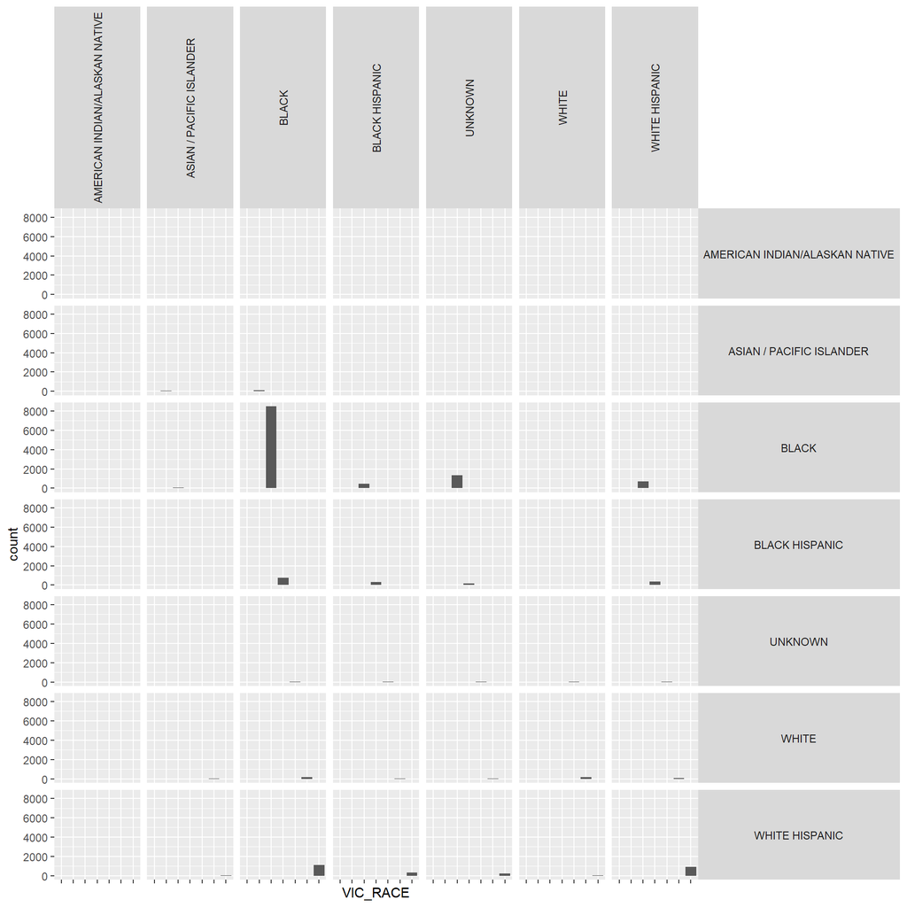

```r
library(RColorBrewer)
ggplot(data = data) + facet_grid(rows = vars(VIC_RACE), cols = vars(PERP_RACE)) + geom_bar(mapping = aes(x = VIC_RACE)) + theme(axis.text.x = element_blank(), legend.position="bottom", strip.text.x = element_text(angle = 90), strip.text.y = element_text(angle = 0))
```

**The black on black incidents seems to be the highest by far. This is a known trend. The white on black incidents are showing as non-existent. This needs to be investigated further.**

### Conclusion

In conclusion we observe that incidents where the perpretrator’s race is Black and victim’s race is also Black seem to be the highest. Locality wise it looks like the highest number of incidents occurred in Brooklyn followed by Bronx.

**Some sources of bias maybe the perpretrator or victim’s race not being collected correctly. This results in a high number for Unknown perpretrator and Black victim cases.**

Regarding personal biases, I realize that I do not belong to a White or hispanic race demographic which may lead to some personal bias on my part. In order to mitigate this bias I should concentrate on the Non-Black data.